# Tutorial 1: Welcome to R

Your first steps in the language we will use all week

**NoteWord list（単語リスト）**

| English | 日本語 | Meaning |
| --- | --- | --- |
| console | コンソール | the window where you type commands to R |
| variable | 変数 | a name that stores a value |
| vector | ベクトル | a list of values kept together |
| function | 関数 | a command that does something, like `mean()` |
| plot | プロット・グラフ | a picture made from data |

## What is R?

**R** is a programming language that scientists use to analyse data and to build **simulations** — small “toy worlds” inside the computer. This week, we will use R to build worlds full of learning agents, and watch what groups of them do together.

Don’t worry if you have never programmed before. You will type everything yourself, one small step at a time.

## Meet RStudio

When you open RStudio, you see (at least) these panels:

- **Console** (bottom-left): type a command, press **Enter**, R answers immediately.
- **Editor** (top-left): write scripts (files of commands) you want to keep.
- **Environment** (top-right): the variables R currently remembers.
- **Plots / Files** (bottom-right): pictures and files appear here.

**TipTry it! — R is a calculator**

Click on the **Console** and type each line, pressing Enter after each:

Predict each answer before you press Enter.

```r
1 + 1
3 * 7
10 / 4
2^10
```

`^` means “to the power of”. So `2^10` is $2^{10}$.

## Variables: giving names to values

We can store a value under a name using `<-` (an arrow: “put into”).

```r
students <- 4
days <- 4
students * days
```

```
[1] 16
```

R remembered `students` and `days`, and used them. Look at the **Environment** panel — your variables are listed there!

## Vectors: many values at once

A **vector** holds several values together. We make one with `c()` (“c” for *combine*):

```r
temperatures <- c(35.5, 37.0, 39.8, 36.2)  # this week in Wako, maybe?
temperatures
```

```
[1] 35.5 37.0 39.8 36.2
```

Functions can work on the whole vector at once:

```r
mean(temperatures)   # average
```

```
[1] 37.125
```

```r
max(temperatures)    # biggest value
```

```
[1] 39.8
```

```r
length(temperatures) # how many values
```

```
[1] 4
```

**TipTry it! — your own vector**

1. Make a vector called `my_numbers` with the ages of everyone in your family.
2. Find the average age with `mean()`.
3. What does `sum(my_numbers)` do? Guess first, then try.

## R can roll dice

This is the most important idea of the whole week: **R can produce randomness**. The function `sample()` picks randomly.

```r
sample(1:6, size = 1)    # roll one die
```

```
[1] 2
```

`1:6` means the whole numbers from 1 to 6.

Run it again. And again. You get different numbers — just like a real die.

```r
sample(1:6, size = 10, replace = TRUE)   # roll ten dice
```

```
 [1] 2 4 1 1 1 5 4 2 6 3
```

(`replace = TRUE` means the same number is allowed to appear again — rolling a 6 doesn’t remove the 6 from the die!)

We can also flip coins:

```r
sample(c("heads", "tails"), size = 5, replace = TRUE)
```

```
[1] "heads" "heads" "heads" "tails" "heads"
```

## Your first plot

```r
rolls <- sample(1:6, size = 1000, replace = TRUE)   # 1000 dice rolls!
```

R made one thousand dice rolls quickly. Let’s look at them:

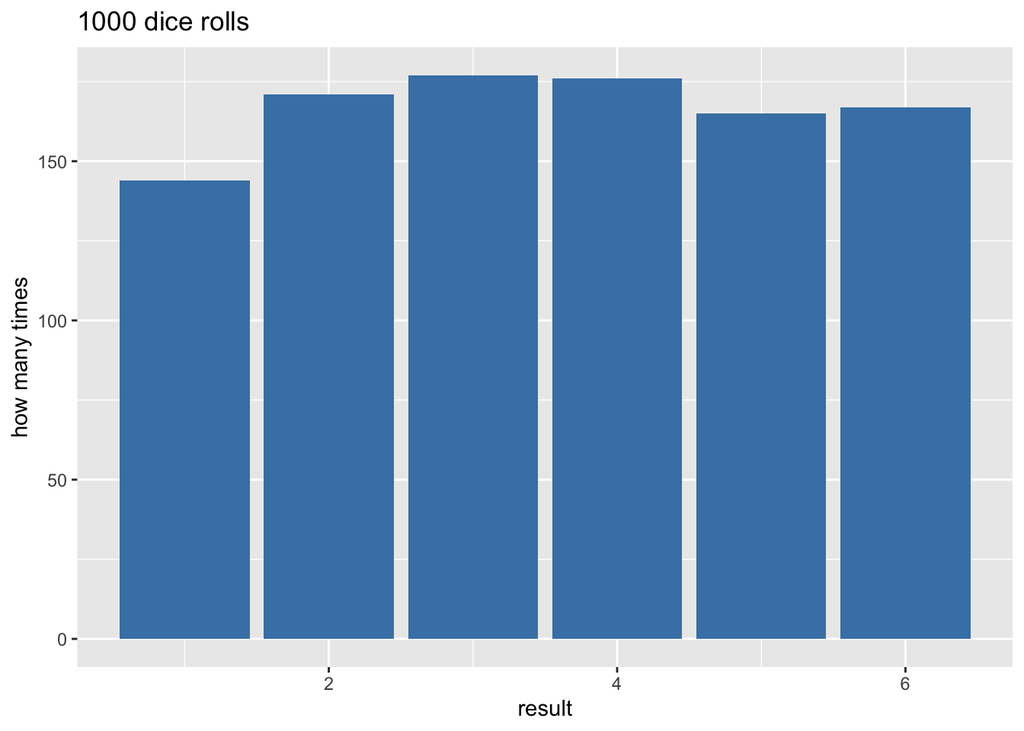

```r
library(ggplot2)
ggplot(data.frame(rolls), aes(x = rolls)) +
  geom_bar(fill = "steelblue") +
  labs(title = "1000 dice rolls", x = "result", y = "how many times")
```

`data.frame()` makes a small table. `ggplot()` always wants its data as a table.

Are all six results equally common? Roughly, yes — but not exactly. Randomness is bumpy. That bumpiness will matter later in the week.

**TipTry it! — unfair dice**

`sample()` can use unequal probabilities:

```r
loaded_rolls <- sample(1:6, size = 1000, replace = TRUE,
                       prob = c(1, 1, 1, 1, 1, 5))
```

1. Plot `loaded_rolls` the same way as above. What changed?
2. Can you make a die that almost never rolls a 1?

Write down your guess before you run the code.

**ImportantThe big idea**

R can generate randomness. This is the engine of every simulation in this camp. Simple random steps can build a model of a much bigger process.

## Getting help

- Error message in red? **Read it slowly** — it usually says what is wrong.
- The 3 most common problems: a missing `)` , a missing `,` , or a typo in a name.
- Ask us! Asking questions is what real researchers do all day.

## What you learned

- R is a calculator that can also remember values (variables) and lists (vectors)
- Functions like `mean()`, `sample()`, `ggplot()` do work for us
- **R can generate randomness** — the engine of every simulation this week

Next tutorial: we use that randomness to build our first **simulation**.